[figure not shown]

# Домашка №4: визуализация

У всех нас есть датасет по контакту. В нём лежит информация про всех нас. Эту информацию надо как следует проанализировать. Именно этим мы сейчас продолжим заниматься. В этот раз с картинками!

В большинстве заданий для получения заветных баллов придётся не только завести код, но и написать свои мысли в поле **Ответ**. Сочинения надо писать прямо в текстовых ячейках, сразу после слова **Ответ**.

Для начала подгрузите все необходимые библиотеки: `math`, `numpy`, `pandas`, `matplotlib.pyplot`, `seaborn` и включите опцию, отвечающую за прорисовку картинок прямо в питонячей тетрадке.

```python
import math
import numpy as np
import pandas as pd

import matplotlib.pyplot as plt
import seaborn as sns
%matplotlib inline
```

Подгрузите данные профилей и данные по фотографиям

```python
# В этой табличке лежат данные по профилю человека
df_profile = pd.read_csv('./vk_data_profile.csv',sep='\t')

# В этой табличке лежат данные по фотографиям человека
df_photo = pd.read_csv('./vk_data_photo.csv',sep='\t')
```

Склеим табличку по полю uid

```python
df = pd.merge(df_profile, df_photo, how='right', on='uid')
df.head()
```

|  | Unnamed: 0_x | uid | Unnamed: 0.1 | first_name | last_name | is_closed | city | home_town | male_dummy | relation_cat | ... | photo_repost_cnt | photo_repost_max | photo_repost_mean | photo_repost_median | photo_text | photo_text_len_cnt | photo_yer_mean | vk_photo_ava_change_cnt | vk_photo_text_url_len_cnt | vk_photo_wall_ph_post_cnt |
| --- | --- | --- | --- | --- | --- | --- | --- | --- | --- | --- | --- | --- | --- | --- | --- | --- | --- | --- | --- | --- | --- |
| 0 | 0 | 182152789 | 0 | Александра | Абашкова | False | Москва | Москва | 0 | не указано | ... | 0.0 | 0.0 | 0.000000 | 0.0 |  | 0.0 | 1.333333 | 0.0 | 0.0 | 0.0 |
| 1 | 1 | 148020433 | 1 | Анастасия | Чуфистова | False | Рязань | Рязань | 0 | не указано | ... | 2.0 | 1.0 | 0.105263 | 0.0 |  | 0.0 | 3.166667 | 0.0 | 0.0 | 0.0 |
| 2 | 2 | 138413935 | 2 | Александр | Головачев | False | Москва | Омск | 1 | не женат/не замужем | ... | 0.0 | 0.0 | 0.000000 | 0.0 |  | 0.0 | 2.333333 | 0.0 | 0.0 | 0.0 |
| 3 | 3 | 366261055 | 3 | Анна | Лобанова | False | NaN | NaN | 0 | не указано | ... | 0.0 | 0.0 | 0.000000 | 0.0 |  | 0.0 | 12.500000 | 0.0 | 0.0 | 0.0 |
| 4 | 4 | 111252392 | 4 | Алексей | Пузырный | False | NaN | NaN | 1 | NaN | ... | 0.0 | 0.0 | 0.000000 | 0.0 |  | 0.0 | 8.750000 | 0.0 | 0.0 | 0.0 |

5 rows × 85 columns

Давайте посмотрим на все названия колонок, которые есть в таблице.

```python
df.columns
```

```
Index(['Unnamed: 0_x', 'uid', 'Unnamed: 0.1', 'first_name', 'last_name',
       'is_closed', 'city', 'home_town', 'male_dummy', 'relation_cat',
       'relation_partner', 'byear', 'bmonth', 'bday', 'country',
       'facebook_dummy', 'instagram_dummy', 'skype_dummy', 'twitter_dummy',
       'home_phone_dummy', 'mobile_phone_dummy', 'site_dummy', 'folowers_cnt',
       'university_str', 'faculty_str', 'about_str', 'activities_str',
       'books_str', 'interests_str', 'movies_str', 'music_str', 'quotes_str',
       'tv_str', 'games_str', 'can_post_dummy', 'can_see_all_posts_dummy',
       'can_see_audio_dummy', 'can_write_private_message_dummy',
       'has_mobile_dummy', 'has_ava_dummy', 'wall_comments_dummy',
       'albums_cnt', 'audio_cnt', 'followers_cnt', 'friends_cnt', 'gifts_cnt',
       'groups_cnt', 'mutual_friends_cnt', 'photos_cnt', 'subscriptions_cnt',
       'user_photos_cnt', 'videos_cnt', 'pages_cnt', 'alco_love_cat',
       'smoke_love_cat', 'religion_str', 'inspired_by_str', 'life_main_cat',
       'people_main_cat', 'political_cat', 'lang_cnt', 'english_dummy',
       'change_city_school_cnt', 'last_bukva_class_str', 'schools_cnt',
       'is_bmm', 'in_hse_memes_group', 'likes_memes', 'Unnamed: 0_y',
       'photo_cnt', 'photo_like_cnt', 'photo_like_max', 'photo_like_mean',
       'photo_like_median', 'photo_month_mean', 'photo_repost_cnt',
       'photo_repost_max', 'photo_repost_mean', 'photo_repost_median',
       'photo_text', 'photo_text_len_cnt', 'photo_yer_mean',
       'vk_photo_ava_change_cnt', 'vk_photo_text_url_len_cnt',
       'vk_photo_wall_ph_post_cnt'],
      dtype='object')
```

Мы видим, что часть из них кончается на `cnt`. Это колонки-счётчики. В них лежат такие переменные как количество фоток, лайков, репостов и тд

```python
variables_cnt = [item for item in df.columns if item[-3:] == 'cnt']
variables_cnt
```

```
['folowers_cnt',
 'albums_cnt',
 'audio_cnt',
 'followers_cnt',
 'friends_cnt',
 'gifts_cnt',
 'groups_cnt',
 'mutual_friends_cnt',
 'photos_cnt',
 'subscriptions_cnt',
 'user_photos_cnt',
 'videos_cnt',
 'pages_cnt',
 'lang_cnt',
 'change_city_school_cnt',
 'schools_cnt',
 'photo_cnt',
 'photo_like_cnt',
 'photo_repost_cnt',
 'photo_text_len_cnt',
 'vk_photo_ava_change_cnt',
 'vk_photo_text_url_len_cnt',
 'vk_photo_wall_ph_post_cnt']
```

Разбиритесь как работает и устроен этот цикл, если вы ещё не разбираетесь. Почитать об этом можно [вот тут.](https://habr.com/ru/post/30232/) Чуть ниже вам предстоит написать свой такой.

**[2]** **Вытащите из переменных счётчиков только те, которые отвечают за фото.** Постройте для них гистограммы (для удобства используйте логарифмическое скалирование). Как думаете, в каких переменных есть выбросы? Какие из переменных неинформативны? Почему?

**Ответ:** photo_repost_cnt, photo_cnt, photo_text_len_cnt, photos_cnt являются переменными с выбросами по той причине, что в них есть некоторые значения, которые далеко находятся от общего скопления точек.

photo_text_len_cnt, vk_photo_wall_ph_post_cnt, vk_photo_ava_change_cnt - неиформативные переменными по той причине, что имеют единичные или 2 значения, которые нельзя сопоставить и вынести полезную информацию чаще всего.

```
array([[<matplotlib.axes._subplots.AxesSubplot object at 0x00000268856547C0>,
      dtype=object)
```

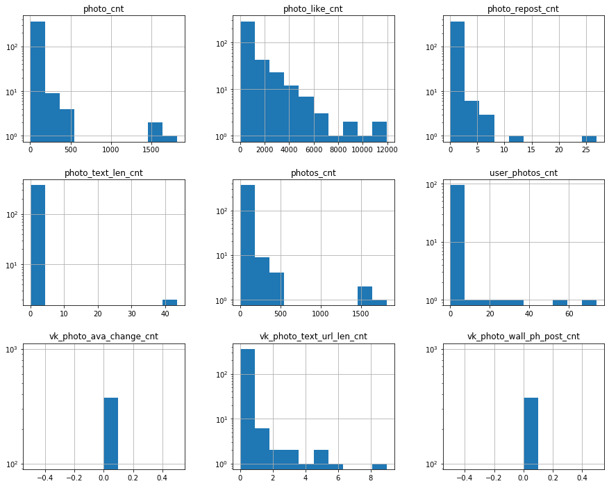

```python
### ╰( ͡° ͜ʖ ͡° )つ──☆ когда вода всемирного потопа кек
photos_var_cnt = [item for item in df.columns if item[-3:] == 'cnt' and 'photo' in item]
df[photos_var_cnt].hist(log=True, figsize=(15,12))
```

```python
# примерно такая картинка должна получиться
```

**[2]** Кто больше постит фотографий, девушки или парни? чьи фото собирают больше лайков? (общее количество лайков, медиана и среднее)

Вы уже до этого искали ответы на подобные вопросы. Тут от вас требуется построить картинку, на которй будет чётко видно что происходит с женщинами, а что с мужчинами (своя гистограмма для каждой фичи раскрашенная по мужчинам и женщинам). Попробуйте построить все $4$ картинки в рамках одной с помощью `axis`.

```python
### ╰( ͡° ͜ʖ ͡° )つ──☆ покинула границы берегов лол
```

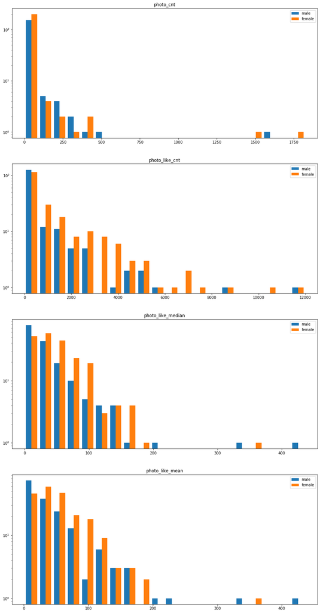

```python
male = df[df['male_dummy'] == 1]
female = df[df['male_dummy'] == 0]
fig, axes = plt.subplots(
    nrows=4, ncols=1,
    figsize=(15, 30))
for num, name in enumerate(['photo_cnt', 'photo_like_cnt', 'photo_like_median','photo_like_mean']):
    axes[num].hist([male[name], female[name]], log=True, bins=20)
    axes[num].set_title(name)
    axes[num].legend(['male', 'female'], loc="upper right")
```

```python
# примерно такая картинка должна получиться
```

Давайте добавим к нашим переменным (описывающим фотографии) количество друзей, количество подарков и пол

```python
photos_var_cnt = ['photo_cnt', 'photo_like_cnt', 'photo_like_median', 'photo_like_mean' ]
vars_interesting = photos_var_cnt + ['male_dummy', 'friends_cnt', 'gifts_cnt']
```

```python
df[vars_interesting].head()
```

|  | photo_cnt | photo_like_cnt | photo_like_median | photo_like_mean | male_dummy | friends_cnt | gifts_cnt |
| --- | --- | --- | --- | --- | --- | --- | --- |
| 0 | 4.0 | 309.0 | 72.0 | 77.250000 | 0 | 298.0 | NaN |
| 1 | 19.0 | 2894.0 | 152.0 | 152.315789 | 0 | 408.0 | 203.0 |
| 2 | 7.0 | 2406.0 | 328.0 | 343.714286 | 1 | 2969.0 | NaN |
| 3 | 50.0 | 1310.0 | 25.0 | 26.200000 | 0 | 214.0 | 24.0 |
| 4 | 35.0 | 1375.0 | 19.0 | 39.285714 | 1 | 336.0 | 227.0 |

**[2]** Визуализируйте вытащенные признаки попарно. Постройте `pairplot` для всех пар. На диагонали расположите оценки плотностей для признаков. Для этого используйте опцию `diag_kind = 'kde'`. С помощью параметра `hue` разбейте все наблюдения на мужские и женские, чтобы они отражались на картинках разными цветами.

```python
### ╰( ͡° ͜ʖ ͡° )つ──☆ из пены уходящего потока
```

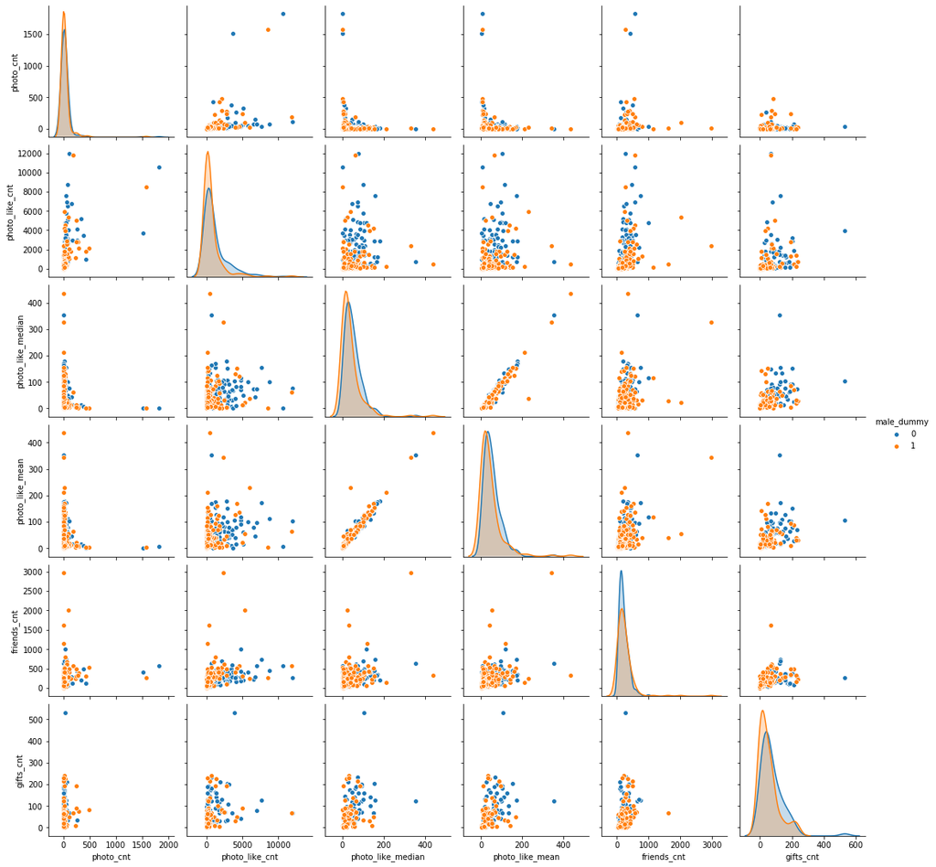

```python
sns.pairplot(df[vars_interesting], diag_kind='kde', hue='male_dummy')
```

Давайте для удобства визуализации прологарифмуем наш датасет (предварительно заполнив пропуски нулями или выкинув их)

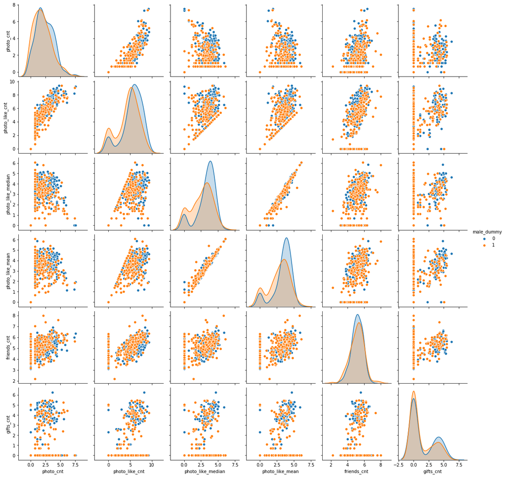

```python
df_na_zero = df[vars_interesting].fillna(0)

for column in df_na_zero.columns:
    if column == 'male_dummy':
        continue
    df_na_zero[column] = df_na_zero[column].map(lambda x: math.log(1 + x))


sns.pairplot(df_na_zero, diag_kind='kde', hue='male_dummy')
```

**[1]** **Сделайте датасет `df_na_drop`. Для этого проделайте всё то же самое, что выше, но вместо того, чтобы заполнять пропуски нулями - выбросите их.**

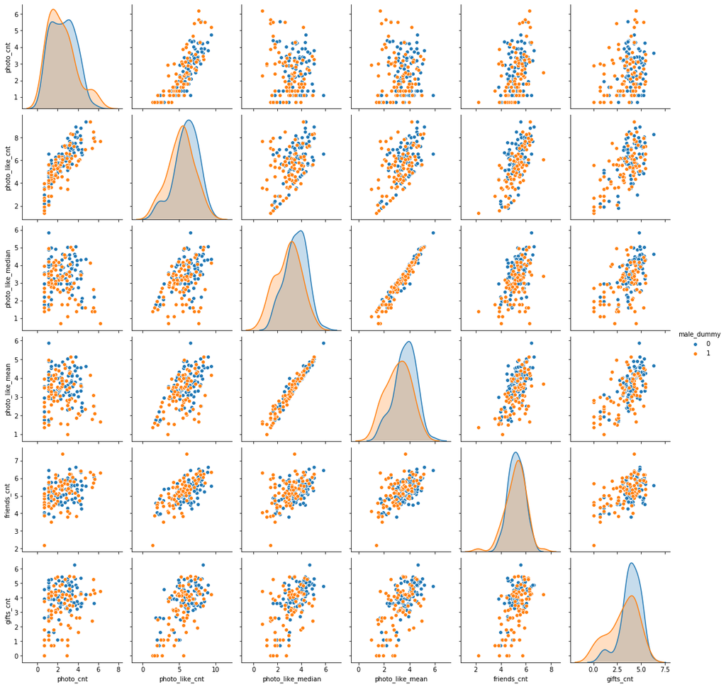

```python
df_na_drop = df[vars_interesting].dropna()

for column in df_na_drop.columns:
    if column == 'male_dummy':
        continue
    df_na_drop[column] = df_na_drop[column].map(lambda x: math.log(1 + x))
sns.pairplot(df_na_drop, diag_kind='kde', hue='male_dummy')
```

**[3]** Дайте ответы на следущие вопросы. Свои мысли пишите прямо здесь!

- Между какими признаками скорее всего есть линейная зависимость? Почему вы так решили?

**Ответ:** Между photos_cnt and photo_like_cnt; photos_cnt and friends_cnt; photo_cnt and photo_like_cnt; photo_cnt and friends_cnt; photo_like_cnt and friends_cnt, photo_like_cnt & gifts_cnt потому что возможно примерно провести прямую линию, в некоторых случаях (как в photo_like_cnt and photo_cnt) предварительно отбросив нижний кластер как выброс.

- Eсть ли тут нелинейные зависимости?

**Ответ:** photos_cnt and gifts_cnt; photo_cnt and gifts_cnt; friends_cnt & photo_cnt, поскольку имеет место существенный разброс данных

- Есть ли объекты-выбросы, которые наблюдаются далеко от сгустков из точек.

**Ответ:** да, есть. Например, во всех переменных с friends_cnt, photo_text_len_cnt.

- Какие ещё интересные особенности вы видите на картинке?

**Ответ:** vk_photo_ava_change_cnt, например, пустая переменная. имеют место переменные, где много пропусков; есть независимых между собой переменные, есть повторяющиеся между собой переменные (пример: photo_cnt и photos_cnt)

**[2]** Отлично! Половина домашки осталась позади. Давайте теперь для тех же самых признаков построим матрицу корреляций и провизуализируем её с помощью `heatmap`.

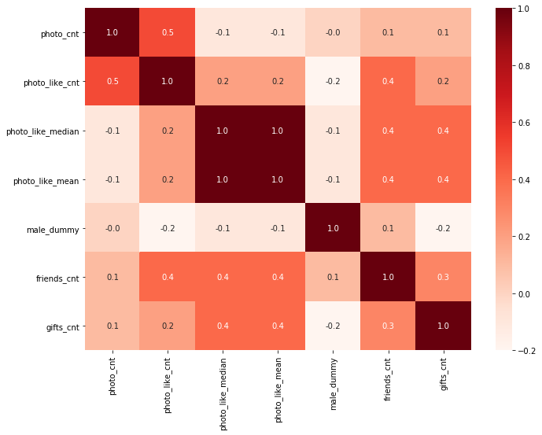

```python
### ╰( ͡° ͜ʖ ͡° )つ──☆ на сушу тихо выбралась любовь

# Тут нужна картинка для датасета df[vars_interesting]
vars_new = ['photo_cnt', 'photo_like_cnt', 'photo_like_median', 'photo_like_mean', 'male_dummy', 'friends_cnt', 'gifts_cnt']
plt.figure(figsize=(11, 8))
sns.heatmap(df[vars_new].corr().round(1), annot=True, cmap='Reds', fmt='.1f')
```

```python
# примерно такая картинка должна получиться
```

```python
df_na_zero = df[vars_new].fillna(0)

for column in df_na_zero.columns:
    if column == 'male_dummy':
        continue
    df_na_zero[column] = df_na_zero[column].map(lambda x: math.log(1 + x))
```

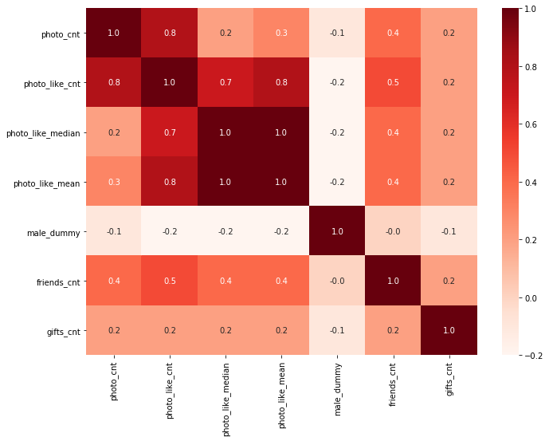

```python
### ╰( ͡° ͜ʖ ͡° )つ──☆ и растворилась в воздухе до срока
plt.figure(figsize=(11, 8))
sns.heatmap(df_na_zero.corr().round(1), annot=True, cmap='Reds', fmt='.1f')
# Тут нужна картинка для датасета df_na_zero[vars_interesting]
```

```python
df_na_drop = df[vars_new].dropna()

for column in df_na_drop.columns:
    if column == 'male_dummy':
        continue
    df_na_drop[column] = df_na_drop[column].map(lambda x: math.log(1 + x))
```

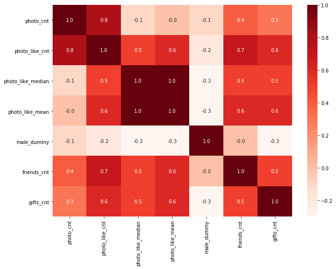

```python
### ╰( ͡° ͜ʖ ͡° )つ──☆ а срока было сорок сороков
plt.figure(figsize=(11, 8))
sns.heatmap(df_na_drop.corr().round(1), annot=True, cmap='Reds', fmt='.1f')
# Тут нужна картинка для датасета df_na_drop[vars_interesting]
```

**[2]** Насколько сильно корреляционные матрицы различаются между собой? Почему?

**Ответ:** Некоторые значения переменные существенно различаются при различных корреляционных матрицах. Значение корреляции в photo_like_cnt & photo_like_mean изменилось на 0.6 во второй по сравнению с первой корреляционной матрицей.

**[2]** Между какими переменными корреляция самая высокая? Почему? Она отрицательная или положительная. Прокомментируйте все клетки, где она оказалась $\ge 0.3$ либо $\le -0.2$.

Положительная сильная корреляция между photo_cnt and photo_like_cnt вызвана тем, что люди, которые выкладывают фотографии по обыкновению более социальны, выкладывая фотографию человек хочет поделиться ею со своими друзьями, соответственно, эти люди в среднем имеют больше друзей и набирают больше лайков. Этим же объясняется высокая положительная корреляция между photo_cnt and friends_cnt.

Интересная ситуация со столбцом male_dummy. Со столбцами photo_like_cnt, photo_like_median/mean, gifts_cnt имеется существенная отрицательная корреляция. Связано это с тем, что парни принимают значение 1, а девушки 0. В нашей культуре принято больше уделять внимание девушкам, соответственно, парни и девушки намного чаще лайкают девушек, а парни парней - крайне редко. Из-за этого формируется перекос лайков на девушек, что создает отрицательную корреляцию.

photo_like_mean and photo_like_cnt имеет высокое корреляционное значение за счет того, что логичным образом чем больше лайков у человека -> тем больше у него в среднем и в медианом лайков на фотках

**[2]** Дамми-переменная это переменная, которая принимает два значения. Либо $1$, если человек обладает закодированным в ней свойством, либо $0$, если не обладает. В нашей таблице все дамми-переменные оканчиваются на суффикc `dummy`.

Возьмите переменную `instagram_dummy`. Она принимает значение $1$, если у пользователя на страничке есть ссылка на инстаграм. Возьмите переменную `male_dummy`. Она примает значение $1$, если пользователь парень. Постройте картинку, на которой будет видно как между собой соотносятся владельцы инстаграмма по полу.

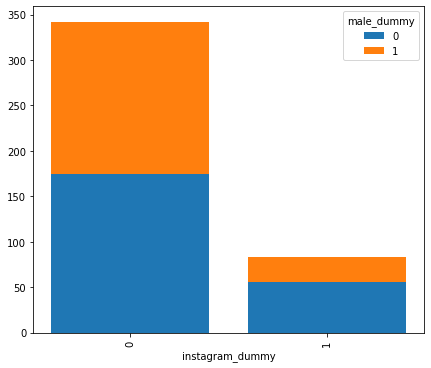

```python
figure, axes = plt.subplots(1, figsize=(7, 6))
axes.set_xticks([0, 1])
axes.set_xlabel('instagram_dummy')
axes.set_xticklabels((0, 1), rotation=90)
first = df[df['male_dummy'] == 0]['instagram_dummy'].value_counts(sort=True)
axes.bar(axes.get_xticks(), first)
axes.bar(axes.get_xticks(), bottom=first, height=df[df.male_dummy == 1]['instagram_dummy'].value_counts(sort=True))
axes.legend(labels=(0, 1), title='male_dummy')
```

```python
# примерно такая картинка должна получиться
```

Правда ли, что девушки чаще указывают наличие инстаграмма на своей страничке?

**Ответ:** да, правда. если число тех, кто не указал инстаграмм среди представителей обоих гендеров примерно одно и то же число, то число тех, кто указал инстаграмм существенно больше половины среди девушек => в процентном отношении число девушек, указавших инстаграмм, больше среди девушек.

**[1]** Категориальная переменная обычно принимает значения из какого-то фиксированного множества. Например, переменная `political_cat` описывает к какой категории относятся политические взгляды юзера. Постройте для этой переменной столбиковую диаграмму. Разбиритесь по [документации](http://seaborn.pydata.org/generated/seaborn.countplot.html#seaborn.countplot) как сделать у столбиков горизонтальное расположение. Можно ли сделать исходя из картинки вывод, что в вышке одни либералы? Почему?

**Ответ:** Нельзя сделать вывод, что в вышке одни либералы из-за того, что: во-первых, в вышке учится в районе 40000 человек, соответственно, проецировать результаты данных опроса 12 человек на такую большую группу будет скорее всего нерепрезентативно во-вторых, в рассматриваемой выборке превалируют люди умеренных политических взглядов, соответственно, никаким образом нельзя сказать из представленных данных, что в вышке одни либералы

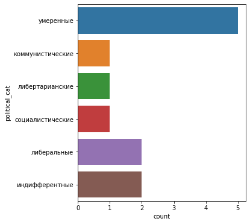

```python
### ╰( ͡° ͜ʖ ͡° )つ──☆ вдыхают грудью эту смесь
fig = plt.figure()
fig.set_size_inches(5, 6)
sns.countplot(y=df['political_cat'])
```

```python
# примерно такая картинка должна получиться
```

**[1]** Как политические взгляды распределены по полам? Постройте для этого также столбиковую диаграмму, на которой каждый стобик будет разбит на два цвета: мужчины и женщины.

**Ответ:** В представленных данных гендерное распределение по политическим взглядам следующее:

индифферентные взгляды имеют 50% парней и 50% девушек

коммунистические взгляды имеют 100% девушки

либеральные взгляды имеют 50% девушек и 50% парней

либертарианские взгляды имеют 100% парней

социалистические взгляды имеют 100% парней

умеренные политические взгляды имеют 40% девушек и 60% парней

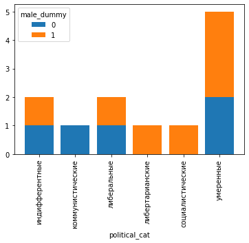

```python
### ╰( ͡° ͜ʖ ͡° )つ──☆ и не преград не ждут ни наказанья
plt.xlabel('political_cat')
plt.xticks(rotation=90)
polit_cat = ['индифферентные', 'коммунистические', 'либеральные', 'либертарианские', 'социалистические', 'умеренные']
female = df[df.male_dummy == 0]['political_cat'].value_counts(sort=True, ascending=False).reindex(polit_cat, fill_value=0)
male = df[df.male_dummy == 1]['political_cat'].value_counts(sort=True, ascending=False).reindex(polit_cat, fill_value=0)
plt.bar(polit_cat, female, label=0)
plt.bar(polit_cat, male, label=1, bottom=female)
plt.legend(title='male_dummy', loc="upper left")
```

```python
# примерно такая картинка должна получиться
```

**[n] Удиви нас. Попробуй найти в данных какую-то классную особенность и визуализируйте её. Если у тебя это получится, мы поставим дополнительные баллы.** Если вы найдёте полную фигню (сколько всего друзей у Маши или типа того), баллов не будет. Найденный факт реально должен выносить мозг и сносить крышу.

```python
### ╰( ͡° ͜ʖ ͡° )つ──☆ и думая что дышат просто так, они внезапно попадают в так такого же неровного дыханья
```

Настрадался? Выскажи всё, что думаешь обо всём этом [в анонимке по четвёртой домашке.](https://docs.google.com/forms/d/e/1FAIpQLSeumKE6K8fB7xZsXneN1KjkV9y_gmLl6wGG7MDiY84HWBUsNg/viewform)